# REDDIT SCORE PREDICTION

## Web Mining

### By : Mira RAHAL & Mohar CHAUDHURI

In this notebook, we perform an analysis on the AskReddit subreddit of Reddit, while providing general insights on the data and proceeding with feature engineering which we will use in building the optimal model that would help us make some predictions of interest.

## Background

Reddit is a popular social media site. On this site, users post threads in various subreddits like r/AskRedidit, r/Jokes, r/data etc. Users can comment on threads or other comments. They can also give upvotes or downvotes to other threads and comments. **Our goal is to predict the number of upvotes that comments will receive**.

## Part 1 : Preliminary steps

```python
# Importing the required packages

# Data manipuation
import pandas as pd
import numpy as np
import datetime
import re

# Visualization
import matplotlib.pyplot as plt
from IPython.display import Image

# Network Mining
import networkx as nx

# Text Mining

import nltk
from nltk.tokenize import word_tokenize
from nltk.tokenize import RegexpTokenizer
from nltk import pos_tag
from nltk.stem import WordNetLemmatizer
from nltk.corpus import stopwords
from sklearn.feature_extraction.text import ENGLISH_STOP_WORDS
from sklearn.model_selection import train_test_split, GridSearchCV
from sklearn.feature_extraction.text import CountVectorizer
from tqdm.auto import tqdm
from sklearn.feature_extraction.text import TfidfVectorizer, CountVectorizer
from sklearn.feature_extraction.text import TfidfTransformer
from sklearn.cluster import MiniBatchKMeans
from sklearn.decomposition import TruncatedSVD
```

### Importing the data

```python
df = pd.read_csv("C:/Users/mirar/Desktop/Web Mining/Project/comments_students/comments_students.csv", header=0)
```

### Overview of the dataset

```python
df.head()
```

|  | created_utc | ups | subreddit_id | link_id | name | subreddit | id | author | body | parent_id | body_cleaned |
| --- | --- | --- | --- | --- | --- | --- | --- | --- | --- | --- | --- |
| 0 | 1430438400 | 3.0 | t5_2qh1i | t3_34f9rh | t1_cqug90j | AskReddit | cqug90j | jesse9o3 | No one has a European accent either because i... | t1_cqug2sr | No one has a European accent either because i... |
| 1 | 1430438400 | 3.0 | t5_2qh1i | t3_34fvry | t1_cqug90k | AskReddit | cqug90k | beltfedshooter | That the kid ..reminds me of Kevin. so sad :-( | t3_34fvry | That the kid reminds me of Kevin so sad |
| 2 | 1430438400 | 5.0 | t5_2qh1i | t3_34ffo5 | t1_cqug90z | AskReddit | cqug90z | InterimFatGuy | NSFL | t1_cqu80zb | NSFL |
| 3 | 1430438401 | 1.0 | t5_2qh1i | t3_34aqsn | t1_cqug91c | AskReddit | cqug91c | JuanTutrego | I'm a guy and I had no idea this was a thing g... | t1_cqtdj4m | Im a guy and I had no idea this was a thing gu... |
| 4 | 1430438401 | 101.0 | t5_2qh1i | t3_34f9rh | t1_cqug91e | AskReddit | cqug91e | dcblackbelt | Mid twenties male rocking skinny jeans/pants, ... | t1_cquc4rc | Mid twenties male rocking skinny jeanspants ha... |

```python
df.shape
```

```
(4234970, 11)
```

There are **4234970** comments.

**Checking for missing values :** there are some NAs in the ups, our variable of interest. This will form our test set. We will deal with the NAs in the *body* later.

```python
df.isna().sum()
```

```
created_utc           0
ups             1016458
subreddit_id          0
link_id               0
name                  0
subreddit             0
id                    0
author                0
body                 61
parent_id             0
body_cleaned          0
dtype: int64
```

```python
## dummy to check if the body of the post is deleted :
df["body_deleted"] = (df["body"].str.contains("deleted",case=False) | df["body"].str.contains("removed",case=False)).astype(int)

df["body_deleted"].sum()/df.shape[0]*100
```

```
7.647563028781786
```

Around 7.6% of the dataset contains comments that either have their author as "deleted" or body as "deleted". We decide to account for these and drop them.  
*P.S : We need to make sure that we only drop rows from the train set and none from the test set.*

**There is an issue**  
The test data contains 63088 rows with either their author or body as deleted. So, in order to be consistent and help the algorithm identify them we have to account for them. In the train set the mean *ups* for these rows is around 4.7, with minimum as -263 and maximum as 4867.

```python
## dummy to check if the author of the post is unknown :
df["author_deleted"] = (df["author"].str.contains("deleted",case=False) | df["author"].str.contains("removed",case=False)).astype(int)

df["author_deleted"].sum()/df.shape[0]*100
```

```
7.3724961451911115
```

## FEATURE ENGINEERING

So, we now try to create some feautures that would be relevant in predicting the score of each comment.

## A) Basic Features

### 1) Number of comments per author

**The idea here is :** If an author who posts more often, i.e., is active, then he has high upscores.

```python
comment_count_author = df[["author"]].value_counts().rename_axis('author').to_frame('comment_count_author')
comment_count_author
```

| author | comment_count_author |
| --- | --- |
| [deleted] | 312007 |
| AutoModerator | 36910 |
| Late_Night_Grumbler | 8298 |
| BiagioLargo | 5843 |
| -_-Equinox666-_- | 2989 |
| ... | ... |
| _the_arab_ | 1 |
| _theRealSlimShady | 1 |
| _theLittlePrince | 1 |
| _thats_not_me_ | 1 |
| Yourothercat | 1 |

570735 rows × 1 columns

We note that, the highest number of comments per author belngs to *[deleted]* and *AutoModerator*.

```python
# merging the feature coomet_count_author to df
df = df.merge(comment_count_author, how='left', on='author')
df.head()
```

|  | created_utc | ups | subreddit_id | link_id | name | subreddit | id | author | body | parent_id | body_cleaned | body_deleted | author_deleted | comment_count_author |
| --- | --- | --- | --- | --- | --- | --- | --- | --- | --- | --- | --- | --- | --- | --- |
| 0 | 1430438400 | 3.0 | t5_2qh1i | t3_34f9rh | t1_cqug90j | AskReddit | cqug90j | jesse9o3 | No one has a European accent either because i... | t1_cqug2sr | No one has a European accent either because i... | 0 | 0 | 54 |
| 1 | 1430438400 | 3.0 | t5_2qh1i | t3_34fvry | t1_cqug90k | AskReddit | cqug90k | beltfedshooter | That the kid ..reminds me of Kevin. so sad :-( | t3_34fvry | That the kid reminds me of Kevin so sad | 0 | 0 | 5 |
| 2 | 1430438400 | 5.0 | t5_2qh1i | t3_34ffo5 | t1_cqug90z | AskReddit | cqug90z | InterimFatGuy | NSFL | t1_cqu80zb | NSFL | 0 | 0 | 57 |
| 3 | 1430438401 | 1.0 | t5_2qh1i | t3_34aqsn | t1_cqug91c | AskReddit | cqug91c | JuanTutrego | I'm a guy and I had no idea this was a thing g... | t1_cqtdj4m | Im a guy and I had no idea this was a thing gu... | 0 | 0 | 5 |
| 4 | 1430438401 | 101.0 | t5_2qh1i | t3_34f9rh | t1_cqug91e | AskReddit | cqug91e | dcblackbelt | Mid twenties male rocking skinny jeans/pants, ... | t1_cquc4rc | Mid twenties male rocking skinny jeanspants ha... | 0 | 0 | 2 |

We note that the maximum number of comments per author belongs to the **[deleted]** author. However, as we know that we also have **[deleted]** authors in the test set , we cannot drop these authors from our train set. Instead, we account for them with the `author_deleted column`.

```python
# let us look at the distribution of the number of comments per author
df.comment_count_author.describe()
```

```
count    4.234970e+06
mean     2.344214e+04
std      8.145337e+04
min      1.000000e+00
25%      8.000000e+00
50%      3.300000e+01
75%      1.490000e+02
max      3.120070e+05
Name: comment_count_author, dtype: float64
```

- if `author` = [deleted] then `comment_count_author` = 1

```python
# To deal with this, what we can do is replace the comment_count column by 1, for the deleted authors,
# as we don't care about their counts and we don't want it to bias the results so for that
df["comment_count_author"] = np.where(df['author']=='[deleted]', 1 , df["comment_count_author"])
```

```python
df.comment_count_author.describe()
```

```
count    4.234970e+06
mean     4.554254e+02
std      3.455065e+03
min      1.000000e+00
25%      5.000000e+00
50%      2.200000e+01
75%      8.800000e+01
max      3.691000e+04
Name: comment_count_author, dtype: float64
```

So we note that, after the modification the statistics have significantly changed. The new average nnumber of comments per author being 455 and maximum dropping to 36910. The standard deviation has alaso significantly dropped.

We also note that we have an author named *AutoModerator*. From the project in the course of Databases, based on the same dataset, we have seen that *AutoModerator* is a system built into reddit that allows moderators to define "rules" (consisting of checks and actions) to be automatically applied to posts in their subreddit.

So in order to account for this, so that our model reads it correctly, we created a new dummy variable `is_AutoModerator` such that :

- if `author`="AutoModerator" then `is_AutoModerator`=1
- else, 0

```python
df["is_AutoModerator"] = np.where(df['author']=='AutoModerator',1,0)
```

### 2) Temporal Features

We will now try to dig deeper into the recency based features. By recency we mean the feautures that are realated to the timing of a comment and that of a link_id. We want to extract the following:

- time: timestamp of comment
- time_lapse: (in seconds) the amount of time since the first comment in a thread
- hour_of_comment: hour of day comment was posted
- weekday: day of week comment was posted

```python
# We first start by, converting create_utc to datetime format
df['time'] = pd.to_datetime(df.created_utc, unit='s')
```

```python
# Find the time of the first comment in a thread/link

first_comment_time = df[['link_id','time']].groupby(by=['link_id']).min()

# Create a dictionary of {link_id -> timestamp} pairs
first_comment_dict = first_comment_time.to_dict('index')

# Create a function that takes in {link_id, timestamp} pair and returs the time elapsed since the first
# comment in that link_id
def time_elapse(x):
    return first_comment_dict[x]['time']

# Add a column of the time_elapsed from the first comment in a link_id
df['time_elapse'] = df.time - df.link_id.apply(time_elapse)

# Convert the type of time_lapse back to seconds
df.time_elapse = df.time_elapse.apply(lambda x:x.total_seconds())
```

```python
# Hour of the comment
df['hour_of_comment'] = df.time.apply(lambda x:x.hour)
# Weekday in which comment was posted
df['weekday'] = df.time.dt.weekday
```

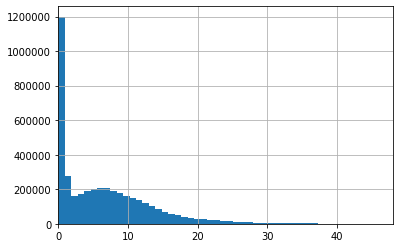

```python
# hours after first comment in thread
(df.time_elapse / (60*60)).hist(bins=800).set_xlim((0, 48));
```

After plotting the distribution of the number of hours elapsing between the link_id and any comment, we clearly note that we have a high number of comments that appear within less than 60 min. Also we see that after around 37 hours, no comments get posted on the same link_id. That is most comment threads die after 37 hours.

### 3) Length of the comments

We want to get the number of words in a comment, without any cleaning, just to see whether the comment is big or small. Generally, people have a tendency to not read long comments.

```python
def get_word_count(df):
    df['word_count'] = df['body'].apply(lambda x: len(str(x).split()))
    return df
get_word_count(df)
```

|  | created_utc | ups | subreddit_id | link_id | name | subreddit | id | author | body | parent_id | body_cleaned | body_deleted | author_deleted | comment_count_author | is_AutoModerator | time | time_elapse | hour_of_comment | weekday | word_count |
| --- | --- | --- | --- | --- | --- | --- | --- | --- | --- | --- | --- | --- | --- | --- | --- | --- | --- | --- | --- | --- |
| 0 | 1430438400 | 3.0 | t5_2qh1i | t3_34f9rh | t1_cqug90j | AskReddit | cqug90j | jesse9o3 | No one has a European accent either because i... | t1_cqug2sr | No one has a European accent either because i... | 0 | 0 | 54 | 0 | 2015-05-01 00:00:00 | 0.0 | 0 | 4 | 21 |
| 1 | 1430438400 | 3.0 | t5_2qh1i | t3_34fvry | t1_cqug90k | AskReddit | cqug90k | beltfedshooter | That the kid ..reminds me of Kevin. so sad :-( | t3_34fvry | That the kid reminds me of Kevin so sad | 0 | 0 | 5 | 0 | 2015-05-01 00:00:00 | 0.0 | 0 | 4 | 10 |
| 2 | 1430438400 | 5.0 | t5_2qh1i | t3_34ffo5 | t1_cqug90z | AskReddit | cqug90z | InterimFatGuy | NSFL | t1_cqu80zb | NSFL | 0 | 0 | 57 | 0 | 2015-05-01 00:00:00 | 0.0 | 0 | 4 | 1 |
| 3 | 1430438401 | 1.0 | t5_2qh1i | t3_34aqsn | t1_cqug91c | AskReddit | cqug91c | JuanTutrego | I'm a guy and I had no idea this was a thing g... | t1_cqtdj4m | Im a guy and I had no idea this was a thing gu... | 0 | 0 | 5 | 0 | 2015-05-01 00:00:01 | 0.0 | 0 | 4 | 14 |
| 4 | 1430438401 | 101.0 | t5_2qh1i | t3_34f9rh | t1_cqug91e | AskReddit | cqug91e | dcblackbelt | Mid twenties male rocking skinny jeans/pants, ... | t1_cquc4rc | Mid twenties male rocking skinny jeanspants ha... | 0 | 0 | 2 | 0 | 2015-05-01 00:00:01 | 1.0 | 0 | 4 | 43 |
| ... | ... | ... | ... | ... | ... | ... | ... | ... | ... | ... | ... | ... | ... | ... | ... | ... | ... | ... | ... | ... |
| 4234965 | 1433116795 | NaN | t5_2qh1i | t3_37y5rx | t1_crrbelu | AskReddit | crrbelu | monster860 | Does the sun set in the west/rise in the east?... | t3_37y5rx | Does the sun set in the westrise in the east Yes | 0 | 0 | 15 | 0 | 2015-05-31 23:59:55 | 44828.0 | 23 | 6 | 11 |
| 4234966 | 1433116795 | NaN | t5_2qh1i | t3_37y5rx | t1_crrbelv | AskReddit | crrbelv | jsimo36 | Coffee. | t3_37y5rx | Coffee | 0 | 0 | 1 | 0 | 2015-05-31 23:59:55 | 44828.0 | 23 | 6 | 1 |
| 4234967 | 1433116796 | NaN | t5_2qh1i | t3_380jx2 | t1_crrbemp | AskReddit | crrbemp | torianicole731 | people who cannot make up their mind, my bulls... | t3_380jx2 | people who cannot make up their mind my bullsh... | 0 | 0 | 5 | 0 | 2015-05-31 23:59:56 | 1881.0 | 23 | 6 | 13 |
| 4234968 | 1433116797 | NaN | t5_2qh1i | t3_37yawp | t1_crrbenh | AskReddit | crrbenh | bellypouch | Give them to Irish people in exchange for doin... | t3_37yawp | Give them to Irish people in exchange for doin... | 0 | 0 | 1 | 0 | 2015-05-31 23:59:57 | 41033.0 | 23 | 6 | 11 |
| 4234969 | 1433116799 | NaN | t5_2qh1i | t3_37zhvy | t1_crrbeop | AskReddit | crrbeop | NotByAnyMeans | classy way to put it | t1_crragip | classy way to put it | 0 | 0 | 38 | 0 | 2015-05-31 23:59:59 | 18828.0 | 23 | 6 | 5 |

4234970 rows × 20 columns

### 4) URL check

We want to distinguish the comments that contain a URL as these comments usually provide some external information that might interest some users. Therefore, we build a new variable that gives the number of linked URLs cited in a comment.

```python
# Regex to extract a link
url_regex = r'https?://(?:[a-zA-Z]|[0-9]|[$-_@.&+]|[!*\(\),]|(?:%[0-9a-fA-F][0-9a-fA-F]))+'

def get_domains(x):
    """
    Given a comment (String), extract an array of urls' domain names mentioned in the comment
    """
    x = str(x)
    urls = re.findall(url_regex, x)
    return urls

# Create the feature for each observation
df['linked_urls'] = df.body.apply(lambda x: get_domains(x))
```

```python
# Create a how-many-urls-were-in-this-comment? feature
df['no_of_linked_urls'] = df['linked_urls'].apply(lambda x: len(x))
```

### 5) Depth of the comment

By depth of a comment, we mean the number of comments that led to this comment in a particular thread (link_id and parent_id).

We care about this feature because we belive that having a higher depth indicates a thread which is interesting. Thus is more likely to have comments with high upscores.

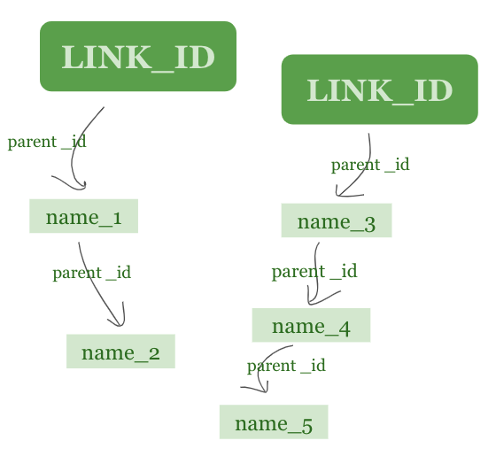

```python
# Load image from local storage
Image(filename = "/Users/moharcd/Desktop/img.png", width = 500, height = 300)
```

```python
# function to create a dictionary presenting the comment names and correponding parent ids
def pd_to_dict(df, index='', column=''):
    return pd.Series(df[column].values, index=df[index]).to_dict()

comment_to_parent_dict = pd_to_dict(df[['name', 'parent_id']],
                                    index='name', column='parent_id')
```

```python
# function to help us calculate the depth
def get_depth(x):
    counter = 0
    temp = x
    while True:
        if temp[:3] == 't3_':
            return counter
        try:
            temp = comment_to_parent_dict[temp]
        except KeyError:
            return counter
        counter += 1
df['depth'] = df['name'].apply(get_depth)
```

### 6) Special characters in a comment

We know that having "!" or "?" usually attracts attention. Comments responding to a question might get more upvotes.

```python
df['contains_?'] = df['body'].str.contains("?", regex=False)
df['contains_?'] = df['contains_?']*1

# We have some NaN bodies so, we get NaN
# We impute these with 0

df['contains_?'] = df['contains_?'].fillna(0)
```

```python
df['contains_!'] = df['body'].str.contains("!", regex=False)
df['contains_!'] = df['contains_!']*1

# We have some NaN bodies so, we get NaN
# We impute these with 0

df['contains_!'] = df['contains_!'].fillna(0)
```

## B) Features based on Network Mining

In this study, we can build several Networks in order to extract interesting features related to comments and authors

### a) Building a network for comments

First step, we build a network linking comments with their parent_ids in order to later compute centrality metrics related to these comments.

Our Network is defined as follows :

- Nodes/ Vertices present comments
- Links are directed such that there exists a link between parent_id and name (which corresponds to a name of the comment) if name is a reply to parent_id

```python
# transfrom dataframe to graph object
c_com = nx.from_pandas_edgelist(df, source="parent_id", target="name", edge_attr = None)
```

```python
print(c_com.number_of_nodes())
print(c_com.number_of_edges())
```

```
4394737
4234970
```

[figure not shown]

```python
# Let us draw a subgraph of a given network in order to have a simple preview of the shape
# Let us take the comment t1_cqu80zb as an example
# Draw subgraph
c_sub = nx.bfs_tree(c_com, "t1_cr4g2bt")
nx.draw(c_sub)
```

This Graph shows that comment "t1_cr4g2bt" is a parent_id to many other comments.

```python
# Listing the nodes of this graph
list(c_sub.nodes)
```

```
['t1_cr4g2bt',
 't3_35hf0v',
 't1_cr4gi5i',
 't1_cr4glf2',
 't1_cr4glsa',
 't1_cr4gseb',
 't1_cr4gtd9',
 't1_cr4gw1g',
 't1_cr4h12q',
 't1_cr4h4zr',
 't1_cr4h6ws',
 't1_cr4he15',
 't1_cr4hq2c',
 't1_cr4ig9c',
 't1_cr4jh5d',
 't1_cr4jke3',
 't1_cr4kihx',
 't1_cr4ljrd',
 't1_cr4lp22',
 't1_cr4mffw',
 't1_cr4mgul',
 't1_cr4mhow',
 't1_cr4mioq',
 't1_cr4oupb',
 't1_cr4pq6t',
 't1_cr4qj17',
 't1_cr4upb9',
 't1_cr4vitl',
 't1_cr4yb5d',
 't1_cr4yepm',
 't1_cr50okn',
 't1_cr50pk9',
 't1_cr52bhh',
 't1_cr52nwy',
 't1_cr54b5j',
 't1_cr57xdy',
 't1_cr58ik9',
 't1_cr59fde',
 't1_cr4fcvn',
 't1_cr4fiez',
```

[output cut: 946 more lines]

```
 't1_cr4v99m',
 't1_cr4wdqw',
 't1_cr4xl6z',
 't1_cr51znz',
 't1_cr5d546',
 't1_cr4xo9y',
 't1_cr4ho2j',
 't1_cr4oena',
 't1_cr4pkcx',
 't1_cr4ttng',
 't1_cr515ka',
 't1_cr4t089',
 't1_cr4vknp',
 't1_cr4r7vb',
 ...]
```

##### Can we compute some metrics related to the Comments ?

From the course, we know that we have 5 centrality metrics which are :

- **Degree Centrality**: Tells us about the number of nearest neighbors to the node. In our application, This feature tells us for each comment, to how many other comments is it connected.
- **Closeness Centrality** : Shows how close an actor is to all other actors in network In our case, How close is this comment to be reached, or reach the other comments
- **Betweeness Centrality** : Measures how much a node has control over all possible pairs of nodes. In our case, it relates to assigning higher values for the comments that are parent_ids for other comments, thus they are between a parent_id and another comment
- **Eigenvector Centrality**: Gives the importance of a node depending on the importance of the neighbors.
- **katz Centrality** :Computes the relative influence of a node within a network by measuring the number of the immediate neighbors (first degree nodes) and also all other nodes in the network that connect to the node under consideration through these immediate neighbors. In our case, this would mainly give us the importance of each parent_id in terms of number of comments it gets

Since, we have seen in the course that the centrality measuresare very correlated (which was confirmed by the results we got from computing these centrality measures on a small subsample of the dataset, we decided to only take degree centrality and eigen vector centrality).

```python
degreeCentrality= nx.degree_centrality(c_com)
```

```python
eigenvectorCentrality = nx.eigenvector_centrality_numpy(c_com, max_iter=200)
```

```python
dCentralities = {"name" : [x for x in degreeCentrality],
                 'degree' : [degreeCentrality[x] for x in degreeCentrality],
                 'eigenVector' : [eigenvectorCentrality[x] for x in eigenvectorCentrality]}
```

```python
dfCentralities = pd.DataFrame.from_dict(dCentralities)
```

```python
df = df.merge(dfCentralities,how='left',on='name')
```

### b) Building a network for author

###### Can we Compute some metrics related to the Authors ?

Second step, we build a network relating the Authors present in the dataset

One interesting feature in predicting the popularity of a comment can be the popularity of the author. Basically, an author who interacts with lots of authors is more likely to have his comment visible and seen by others, therefore it's more likely to be upvoted or downvoted.

A first attempt was to build our Network in the following way:

- Nodes represent Authors
- Edges represent link between authors, which exists when two authors have the same parent_link, i.e, comment on the same comment

However, after trials of different methods (Found in file, 'Extra Attempted Work'), and after discussing with Prof Yoann, we discovered that it was not possible to build this Network with our computers.

Thus, we moved to defining the Network in the following way

- Nodes represent Authors
- Edges represent link between the author of the comment and the author of the parent_id of this comment

```python
# Building this Network
df['parent_author'] = df['parent_id'].map(df.set_index('name')['author'])
```

```python
# Let us look at what we will get
authors_parents = df[["author","parent_author"]]
```

```python
authors_parents
```

|  | author | parent_author |
| --- | --- | --- |
| 0 | jesse9o3 | NaN |
| 1 | beltfedshooter | NaN |
| 2 | InterimFatGuy | NaN |
| 3 | JuanTutrego | NaN |
| 4 | dcblackbelt | NaN |
| ... | ... | ... |
| 4234965 | monster860 | NaN |
| 4234966 | jsimo36 | NaN |
| 4234967 | torianicole731 | NaN |
| 4234968 | bellypouch | NaN |
| 4234969 | NotByAnyMeans | naveb2015 |

4234970 rows × 2 columns

We see here that we have lots of authors of parent ids that are unknow, and this is mainly because in our data, we don't have all the information related to all parent_ids. Thus, we decide to build the network for the authors for which we know the parents

```python
authors_interest = ~ authors_parents['parent_author'].isna()
authors_interest = authors_parents[authors_interest]
authors_interest
```

|  | author | parent_author |
| --- | --- | --- |
| 157 | Late_Night_Grumbler | sonovadoyle |
| 171 | 7up478 | youthfulvictim |
| 176 | Eryius | Racetyme |
| 236 | Ask_Threadit | Eryius |
| 237 | upsidedowntyper | Racetyme |
| ... | ... | ... |
| 4234961 | muffintaupe | Universal-Cereal-Bus |
| 4234962 | TheVoiceOfRiesen | poopsy__daisy |
| 4234963 | sharks_in_my_vagina | clouddevourer |
| 4234964 | YoungAdult_ | MephistoSchreck |
| 4234969 | NotByAnyMeans | naveb2015 |

2510195 rows × 2 columns

```python
a_com = nx.from_pandas_edgelist(authors_interest, source='parent_author', target = 'author', edge_attr=None)
```

```python
print(a_com.number_of_nodes())
print(a_com.number_of_edges())
```

```
411972
1778717
```

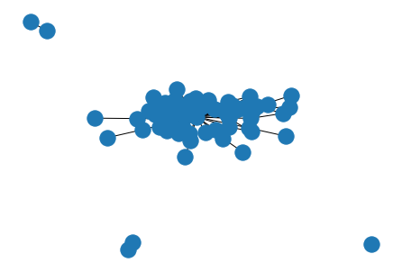

```python
# To show a small example on how this network looks like we first get the nodes of this network
a_nodes = list(a_com.nodes)
# We choose to show connections of 60 nodes
a_sub = a_com.subgraph(a_nodes[:60])
nx.draw(a_sub)
```

We noticed from the graph that some nodes are not connected to any other nodes.

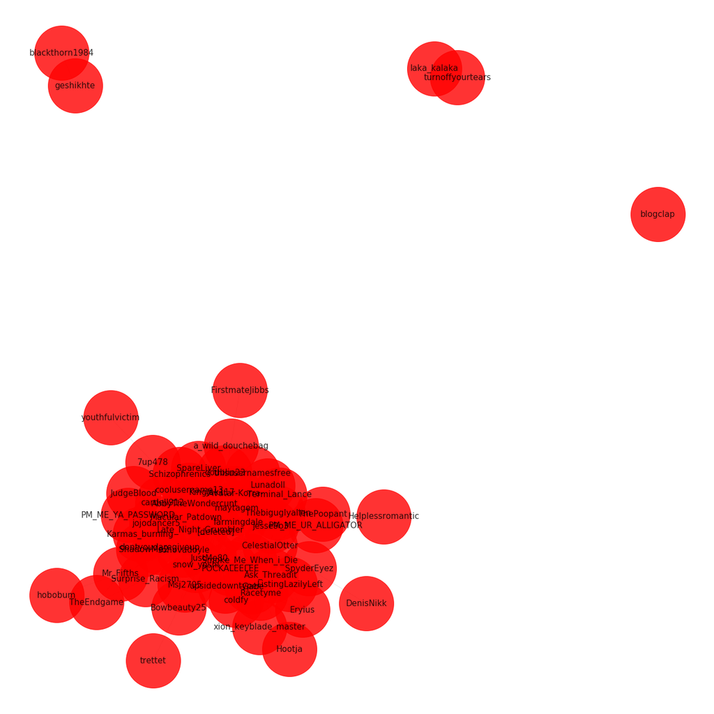

```python
# Improving the representation of the subgraph
options = {
    'node_color' : 'red', # a list that contains the community id for the nodes we want to plot
    'node_size' : 10000,
    'cmap' : plt.get_cmap("jet"),
    'node_shape' : 'o',
    'with_labels' : True,
    "width" : 0.1,
    "font_size" : 15,
    "nodelist" : a_sub.nodes, # A list that contains the labels of the nodes we want to plot
    "alpha" : 0.8
}

plt.figure(figsize=(18,18))
nx.draw(a_sub,**options)
```

```python
#Let us compute metrics for the authors
degreeCentrality_author= nx.degree_centrality(a_com)
```

```python
eigenvectorCentrality_author = nx.eigenvector_centrality_numpy(a_com, max_iter=200)
```

```python
dCentralities_author = {"author" : [x for x in degreeCentrality_author],
                        'degree_author' : [degreeCentrality_author[x] for x in degreeCentrality_author],
                        'eigenVector_author' : [eigenvectorCentrality_author[x] for x in eigenvectorCentrality_author]}
```

```python
dfCentralities_author = pd.DataFrame.from_dict(dCentralities_author)
dfCentralities_author.head(10)
```

|  | author | degree_author | eigenVector_author |
| --- | --- | --- | --- |
| 0 | sonovadoyle | 0.000468 | 0.003774 |
| 1 | Late_Night_Grumbler | 0.006610 | 0.022246 |
| 2 | youthfulvictim | 0.000007 | 0.000034 |
| 3 | 7up478 | 0.000728 | 0.004618 |
| 4 | Racetyme | 0.000046 | 0.002443 |
| 5 | Eryius | 0.000036 | 0.000113 |
| 6 | Ask_Threadit | 0.000828 | 0.005055 |
| 7 | upsidedowntyper | 0.000039 | 0.002476 |
| 8 | Hootja | 0.000007 | 0.000029 |
| 9 | ListingLazilyLeft | 0.000012 | 0.000056 |

```python
df = df.merge(dfCentralities_author,how='left',on='author')
```

## C) Features based on Text Mining

In this section, we extract some features that we found interesting from the Text Mining point of approach.

As we know that comments in a social networking site usually contains lots of textual lingo and emoticons, which do not related to the uniqueness of the content of a ceratin comment we decide to clean bodies of the comments in our dataset in such a way that we:

- remove @ mentions
- remove the '#' symbol
- remove special characters
- remove the hyperlink
- remove email address
- remove numbers
- remove one character word

```python
# function to do basic cleaning
def cleanTxt(text):
    text = str(text)
    text = re.sub(r'@[A-Za-z0-9]+',
                 '',
                 text) # removing @ mentions if any
    text = re.sub(r'#',
                 '',
                 text) # removing the '#' symbol
    text = re.sub('[^a-zA-z0-9\s]',
                  '',
                  text) # remove special characters
    text = re.sub(r'https?:\/\/\S+',
                 '',
                 text) # remove the hyperlink
    text = re.sub(r'https?\S+',
                 '',
                 text) # remove the hyperlink
    text = re.sub(r'\S*@\S*\s?',
                 '',
                 text) # remove email address
    text = text.replace('\r', ' ').replace('\n', ' ') # remove line breaks
    text = re.sub(r'\d+',
                  '',
                  text) # remove numbers
    return text
body_cleaned = pd.Series([cleanTxt(i) for i in tqdm(df.body)])
df['body_cleaned']=body_cleaned.values
```

```python
# remove one character word
def remove_one_character_words(text):
    '''Remove words from dataset that contain only 1 character'''
    text_high_use = [token for token in word_tokenize(text) if len(token)>1]
    return ' '.join(text_high_use)
body_cleaned = pd.Series([lowercase(i) for i in tqdm(df.body_cleaned)])
df['body_cleaned'] = body_cleaned.values
```

Further, we also converted the text into lower characters and removed the stopwords in english. Stopwords are the English words which does not add much meaning to a sentence. They can safely be ignored without sacrificing the meaning of the sentence. For example, the words like the, he, have etc.

*“Lemmatization usually refers to doing things properly with the use of a vocabulary and morphological analysis of words, normally aiming to remove inflectional endings only and to return the base or dictionary form of a word, which is known as the lemma….a lemmatizer, which needs a complete vocabulary and morphological analysis to correctly lemmatize words…”*

```python
# convert to lower case text
def lowercase(text):
    text_low = [token.lower() for token in word_tokenize(text)]
    return ' '.join(text_low)
body_cleaned = pd.Series([lowercase(i) for i in tqdm(df.body_cleaned)])
df['body_cleaned'] = body_cleaned.values
```

```python
# remove stop words in English
def remove_stopwords(text):
    stop = set(stopwords.words('english'))
    word_tokens = nltk.word_tokenize(text)
    text = " ".join([word for word in word_tokens if word not in stop])
    return text
body_cleaned = pd.Series([remove_stopwords(i) for i in tqdm(df.body_cleaned)])
df['body_cleaned'] = body_cleaned.values
```

```python
def Lemmatize(text):
    tokens = word_tokenize(text)
    tokens = [stemmer.stem(x) for x in tokens]
    text = ' '.join([lemmatizer.lemmatize(x,pos="v") for x in tokens])
    return
lemma = pd.Series([remove_stopwords(i) for i in tqdm(df.body_cleaned)])
df['body_cleaned'] = lemma.values
```

The motivation behind doing this cleaning is firstly for getting the number of 'significant' words in a comment as this number can be an indicator on the importance/attractiveness of a comment. Secondly, these extracted words would help us in allocating the comments to a particular topic.

After this rigorously cleaning, we want to again count the number of words and create another feature **word_count_cleaned**.

```python
def get_word_count(df):
    df['word_count_cleaned'] = df['body_cleaned'].apply(lambda x: len(str(x).split()))
    return df
get_word_count(df)
```

|  | created_utc | ups | subreddit_id | link_id | name | subreddit | id | author | body | parent_id | ... | no_of_linked_urls | depth | contains_? | contains_! | degree | eigenVector | parent_author | degree_author | eigenVector_author | word_count_cleaned |
| --- | --- | --- | --- | --- | --- | --- | --- | --- | --- | --- | --- | --- | --- | --- | --- | --- | --- | --- | --- | --- | --- |
| 0 | 1430438400 | 3.0 | t5_2qh1i | t3_34f9rh | t1_cqug90j | AskReddit | cqug90j | jesse9o3 | No one has a European accent either because i... | t1_cqug2sr | ... | 0 | 1 | 0 | 0 | 2.275450e-07 | 1.246349e-20 | NaN | 0.000141 | 0.002698 | 10 |
| 1 | 1430438400 | 3.0 | t5_2qh1i | t3_34fvry | t1_cqug90k | AskReddit | cqug90k | beltfedshooter | That the kid ..reminds me of Kevin. so sad :-( | t3_34fvry | ... | 0 | 1 | 0 | 0 | 2.275450e-07 | -2.709494e-20 | NaN | 0.000007 | 0.000027 | 4 |
| 2 | 1430438400 | 5.0 | t5_2qh1i | t3_34ffo5 | t1_cqug90z | AskReddit | cqug90z | InterimFatGuy | NSFL | t1_cqu80zb | ... | 0 | 1 | 0 | 0 | 2.275450e-07 | 1.219674e-20 | NaN | 0.000160 | 0.002886 | 1 |
| 3 | 1430438401 | 1.0 | t5_2qh1i | t3_34aqsn | t1_cqug91c | AskReddit | cqug91c | JuanTutrego | I'm a guy and I had no idea this was a thing g... | t1_cqtdj4m | ... | 0 | 1 | 0 | 0 | 2.275450e-07 | 3.730854e-20 | NaN | NaN | NaN | 5 |
| 4 | 1430438401 | 101.0 | t5_2qh1i | t3_34f9rh | t1_cqug91e | AskReddit | cqug91e | dcblackbelt | Mid twenties male rocking skinny jeans/pants, ... | t1_cquc4rc | ... | 0 | 1 | 0 | 0 | 4.550899e-07 | 3.370706e-20 | NaN | 0.000005 | 0.000020 | 27 |
| ... | ... | ... | ... | ... | ... | ... | ... | ... | ... | ... | ... | ... | ... | ... | ... | ... | ... | ... | ... | ... | ... |
| 4234965 | 1433116795 | NaN | t5_2qh1i | t3_37y5rx | t1_crrbelu | AskReddit | crrbelu | monster860 | Does the sun set in the west/rise in the east?... | t3_37y5rx | ... | 0 | 1 | 1 | 0 | 2.275450e-07 | -5.923341e-20 | NaN | 0.000029 | 0.000069 | 5 |
| 4234966 | 1433116795 | NaN | t5_2qh1i | t3_37y5rx | t1_crrbelv | AskReddit | crrbelv | jsimo36 | Coffee. | t3_37y5rx | ... | 0 | 1 | 0 | 0 | 2.275450e-07 | -1.023230e-19 | NaN | NaN | NaN | 1 |
| 4234967 | 1433116796 | NaN | t5_2qh1i | t3_380jx2 | t1_crrbemp | AskReddit | crrbemp | torianicole731 | people who cannot make up their mind, my bulls... | t3_380jx2 | ... | 0 | 1 | 0 | 0 | 2.275450e-07 | 3.323486e-20 | NaN | 0.000010 | 0.000088 | 7 |
| 4234968 | 1433116797 | NaN | t5_2qh1i | t3_37yawp | t1_crrbenh | AskReddit | crrbenh | bellypouch | Give them to Irish people in exchange for doin... | t3_37yawp | ... | 0 | 1 | 0 | 0 | 2.275450e-07 | 7.829613e-20 | NaN | NaN | NaN | 5 |
| 4234969 | 1433116799 | NaN | t5_2qh1i | t3_37zhvy | t1_crrbeop | AskReddit | crrbeop | NotByAnyMeans | classy way to put it | t1_crragip | ... | 0 | 7 | 0 | 0 | 2.275450e-07 | 2.664985e-20 | naveb2015 | 0.000262 | 0.003200 | 3 |

4234970 rows × 31 columns

```python
# to illustrate the change in text after cleaning
df.loc[1,['word_count','word_count_cleaned','body','body_cleaned']]
```

```
word_count                                                          10
word_count_cleaned                                                   4
body                  That the kid ..reminds me of Kevin.   so sad :-(
body_cleaned                                     kid reminds kevin sad
Name: 1, dtype: object
```

Now that we have a clean corpus of text, we proceed to do topic modelling.

### Hard Clustering

We know that some comments can receive high up votes if their topic is very trending. This is why we decide to extract some topics and add a feature relating to the topic of each comment.

To extract the topics, we had a choice between implementing several unsupervised learning algorithms. A speacility to these types of algorithms is that no labels are given to the learning algorithm, leaving it on its own to find structure in its input.Unsupervised learning can be a goal in itself (discovering hidden patterns in data) or a means towards an end (feature learning).

From what we have seen in the course, we decide to work with **Hard Clustering** which is a clustering tenchnique that differs from Soft Clustering, as in the former case each data point belongs to only one cluster, unlike the latter.

```python
# creating the corpus of text
corpus = []
for row in range(0,4234970) :
    corpus.append(''.join(str(x) for x in df.iloc[row,10]))
```

Word Embedding is a technique where we can represent the text using vectors. The more popular forms of word embeddings are:

- BoW, which stands for Bag of Words
- TF-IDF, which stands for Term Frequency-Inverse Document Frequency

TF-IDF is very common algorithm to transform text into a meaningful representation of numbers which is used to fit machine algorithm for prediction.

```python
# Term Frequency Inverse Document Frequency.
n_features = 1000 # vocabulary size
vectorizer = TfidfVectorizer(max_df=0.02,
                             max_features=n_features,
                             min_df=0.001,
                             stop_words='english',
                             use_idf=True)
```

```python
# bag of words
bag_of_words = vectorizer.fit_transform(corpus)
print("n_samples: %d, n_features: %d" % bag_of_words.shape)
```

```
n_samples: 4234970, n_features: 1000
```

```python
# Implementing k-means algorithm as our hard clustering algorithm
km = MiniBatchKMeans(n_clusters=20)
km.fit(bag_of_words)
km.labels_
```

```
array([13,  3, 13, ..., 15, 13, 13])
```

```python
# giving us some common words in each cluster if we want to do text conceptualization later
order_centroids = km.cluster_centers_.argsort()[:, ::-1]
terms = vectorizer.get_feature_names()
for i in range(20):
    print("Cluster %d:" % i, end='')
    for ind in order_centroids[i, :10]:
        print(' %s' % terms[ind], end='')
    print()
```

```
Cluster 0: named helps lives car house little forward forgot gives given
Cluster 1: thank awesome hand dog baby black song water glad room
Cluster 2: related removed subreddit action contact looking post reviewadada requestampampmessagemy topic
Cluster 3: death eat wait dick problem power source hell matter ok
Cluster 4: love fuck id yeah fucking mean best reddit man try
Cluster 5: ass called open dude joke toilet red white balls link
Cluster 6: easily hold food favorite id generally gets getting girl youve
Cluster 7: understand finally okay youll far band racist fuck happening language
Cluster 8: ones probably paper dead bad read gets gay general generally
Cluster 9: legal longer god gt saying form gas gives given girls
Cluster 10: meet man finally lets title sex gave gay general generally
Cluster 11: universe wall supposed game given girls girlfriend girl getting gets
Cluster 12: energy students learning math degree learned specific youve course water
Cluster 13: true haha nope ice shower op late run cool okay
Cluster 14: food eat eating actual american different form dog career red
Cluster 15: talk sorry works penis explain story google reading happen super
Cluster 16: sounds awesome damn wife use illegal regular awful quickly character
Cluster 17: ah use crap order forget months mind ago thank old
Cluster 18: metal trouble moving hurt ok hit big school little girlfriend
Cluster 19: movie fun great best makes guy fuck love fact episode
```

```python
# getting prediction for our bag of words
result = km.fit_predict(bag_of_words)
result
```

```
array([10,  1, 10, ..., 10, 10, 10])
```

```python
# for each cluster we are counting the number of comments in it
clusterDocs = {}
for idDoc, clusterId in enumerate (result):
  clusterDocs.setdefault(clusterId,[])
  clusterDocs[clusterId].append(idDoc)
```

```python
{x: len(clusterDocs[x]) for x in clusterDocs}
```

```
{10: 1564664,
 1: 2541006,
 0: 12995,
 7: 41446,
 9: 34004,
 13: 4860,
 17: 1451,
 4: 2003,
 11: 2402,
 5: 8642,
 14: 1873,
 2: 7200,
 16: 3085,
 12: 2652,
 19: 3067,
 3: 845,
 8: 2741,
 15: 17,
 18: 6,
 6: 11}
```

```python
# appending the feature to our dataset
df["Hard_Cluster"] = result
df.head(5)
```

|  | created_utc | ups | subreddit_id | link_id | name | subreddit | id | author | body | parent_id | ... | depth | contains_? | contains_! | degree | eigenVector | parent_author | degree_author | eigenVector_author | word_count_cleaned | Hard_Cluster |
| --- | --- | --- | --- | --- | --- | --- | --- | --- | --- | --- | --- | --- | --- | --- | --- | --- | --- | --- | --- | --- | --- |
| 0 | 1430438400 | 3.0 | t5_2qh1i | t3_34f9rh | t1_cqug90j | AskReddit | cqug90j | jesse9o3 | No one has a European accent either because i... | t1_cqug2sr | ... | 1 | 0 | 0 | 2.275450e-07 | 1.246349e-20 | NaN | 0.000141 | 0.002698 | 10 | 10 |
| 1 | 1430438400 | 3.0 | t5_2qh1i | t3_34fvry | t1_cqug90k | AskReddit | cqug90k | beltfedshooter | That the kid ..reminds me of Kevin. so sad :-( | t3_34fvry | ... | 1 | 0 | 0 | 2.275450e-07 | -2.709494e-20 | NaN | 0.000007 | 0.000027 | 4 | 1 |
| 2 | 1430438400 | 5.0 | t5_2qh1i | t3_34ffo5 | t1_cqug90z | AskReddit | cqug90z | InterimFatGuy | NSFL | t1_cqu80zb | ... | 1 | 0 | 0 | 2.275450e-07 | 1.219674e-20 | NaN | 0.000160 | 0.002886 | 1 | 10 |
| 3 | 1430438401 | 1.0 | t5_2qh1i | t3_34aqsn | t1_cqug91c | AskReddit | cqug91c | JuanTutrego | I'm a guy and I had no idea this was a thing g... | t1_cqtdj4m | ... | 1 | 0 | 0 | 2.275450e-07 | 3.730854e-20 | NaN | NaN | NaN | 5 | 1 |
| 4 | 1430438401 | 101.0 | t5_2qh1i | t3_34f9rh | t1_cqug91e | AskReddit | cqug91e | dcblackbelt | Mid twenties male rocking skinny jeans/pants, ... | t1_cquc4rc | ... | 1 | 0 | 0 | 4.550899e-07 | 3.370706e-20 | NaN | 0.000005 | 0.000020 | 27 | 1 |

5 rows × 32 columns

Before concluding this section, we would like to note that we also tried to implement an advanced soft clustering technique Latent Dirichlet Allocation. It worked well in a small subsample but for the wole data set, it was difficult to implement. The attempt is cited in the 'Extra Attempted Work'.

## D) Features built with a mixture of text mining and network mining

In this section, we use the results we got from the implementation of hard clustering to build a network of authors within each cluster. The motivation behind this idea is that we believe that some authors may be very popular in a specific topic thus their comment on this topic might attract a lot of attention. Previously, we have computed centrality metrics for the authors with respect to the whole data, which might underestimate the 'influence' of osme authors who are very influential only in their circle. This is why we decide to compute the centrality metrics of each author with the restriction on the topic.

Our method is implemented by the following steps.

```python
# We start start by creating a dataframe with respect to each author and each Hard Cluster
author_and_clusters = pd.DataFrame({'author':df.author,'Hard_cluster':df.Hard_Cluster})

# Then, we do a groupby on authors
group = author_and_clusters.groupby('author')

# extract the unique clusters for each author, as some authors might comment on different topics
dictionary_author_cluster = group['Hard_cluster'].unique()
dictionary_author_cluster = dict(dictionary_author_cluster)
count_hc = pd.DataFrame(list(dictionary_author_cluster.items()),columns = ['author','author_hard_clusters'])
```

```python
# add a feature based on the number of topics in which an author comments
count_hc['author_nb_hard_clusters']=count_hc['author_hard_clusters'].apply(lambda x: len(x))
df = df.merge(count_hc, how = 'left', on = 'author')
```

```python
# We create 20 different dataframes each for a topic
for i, g in df.groupby('Hard_Cluster'):
    globals()['df_' + str(i)] =  g
```

```python
# create a function that:
# - builds a network between the authors in a particular topic
# - extracts the dgree centrality measure of this network of authors
def topic_network(df):
    parent_author = df['parent_id'].map(df.set_index('name')['author'])
    authors_parents = df[["author","parent_author"]]
    authors_interest = ~ authors_parents['parent_author'].isna()
    authors_interest = authors_parents[authors_interest]
    a_com = nx.from_pandas_edgelist(authors_interest, source='parent_author', target = 'author', edge_attr=None)
    degreeCentrality_author= nx.degree_centrality(a_com)
    dCentralities_author = {"author" : [x for x in degreeCentrality_author],
                        'degree_author_topic' : [degreeCentrality_author[x] for x in degreeCentrality_author]}
    dfCentralities_author = pd.DataFrame.from_dict(dCentralities_author)
    df = df.merge(dfCentralities_author,how='left',on='author')
    return df
```

```python
# apply the above created function and merge all the 20 different dataframes together to one single dataframe
df = df.groupby('Hard_Cluster').apply(topic_network)
```

```python
# droppping the index
df.reset_index(drop=True, inplace=True)
```

```python
# checking the shape
df.shape
```

```
(4234970, 35)
```

```python
# Saving all our features for modelling so that we do not have to run them everytime
df.to_pickle('final_features.pkl')
```

[output not shown]